# Lab 7

Yehudis

10/28/2020

1. A test-taker answered 50 true/false questions and received a score of 60% correct. Report the results of a binomial test and explain whether you think the test-score could be produced by the test-taker randomly guessing on each question. (2 points)

```r
binom.test(x=30,
           n=50,
           alternative = "greater")
```

```
##
##  Exact binomial test
##
## data:  30 and 50
## number of successes = 30, number of trials = 50, p-value = 0.1013
## alternative hypothesis: true probability of success is greater than 0.5
## 95 percent confidence interval:
##  0.4738803 1.0000000
## sample estimates:
## probability of success
##                    0.6
```

```r
binom.test(x=30,
           n=50,
           alternative = "two.sided")
```

```
##
##  Exact binomial test
##
## data:  30 and 50
## number of successes = 30, number of trials = 50, p-value = 0.2026
## alternative hypothesis: true probability of success is not equal to 0.5
## 95 percent confidence interval:
##  0.4517940 0.7359216
## sample estimates:
## probability of success
##                    0.6
```

```r
# Explanation:
#   Assuming an alpha of .05, the test-score for 50 T/F questions can plausibly be 60% when randomly guessing on all 50 questions, because the p-value of 60% or more correct of 50 fair binomial questions is .10 (10% chance), which means that we fail to reject the null hypothesis.
#
#   When running the test two sided (not asking about greater or less than 60% success, the p-value is .20, which is also more than .05 and therefore) this result can occur by chance.
```

2. An examiner wants to make a TRUE/FALSE test, but is still deciding how many questions they will include. They want to make sure that it would be very difficult to simply randomly guess and be able to score any higher than 55% percent. How many questions would the examiner need to use to be confident that scores of 55% or higher were not produced by chance? (2 points)

```r
binom.test(x=220,
           n=400,
           alternative="greater")
```

```
##
##  Exact binomial test
##
## data:  220 and 400
## number of successes = 220, number of trials = 400, p-value = 0.02552
## alternative hypothesis: true probability of success is greater than 0.5
## 95 percent confidence interval:
##  0.507659 1.000000
## sample estimates:
## probability of success
##                   0.55
```

3. A test has 5 TRUE/FALSE questions (each with one right answer) and 5 multiple choice questions with four choices each (each with only one right answer).
- create a sampling distribution or probability distribution to illustrate how a random chance process could perform on this test. (1 point)
- What is the probability that randomly guessing on each question could allow a person to receive 75% or greater on this test? (1 point)

```r
rbinom(n = rep(1,10), size = 1, prob = c(.5,.5,.5,.5,.5,.25,.25,.25,.25,.25))
```

```
##  [1] 0 1 1 1 0 0 0 0 0 0
```

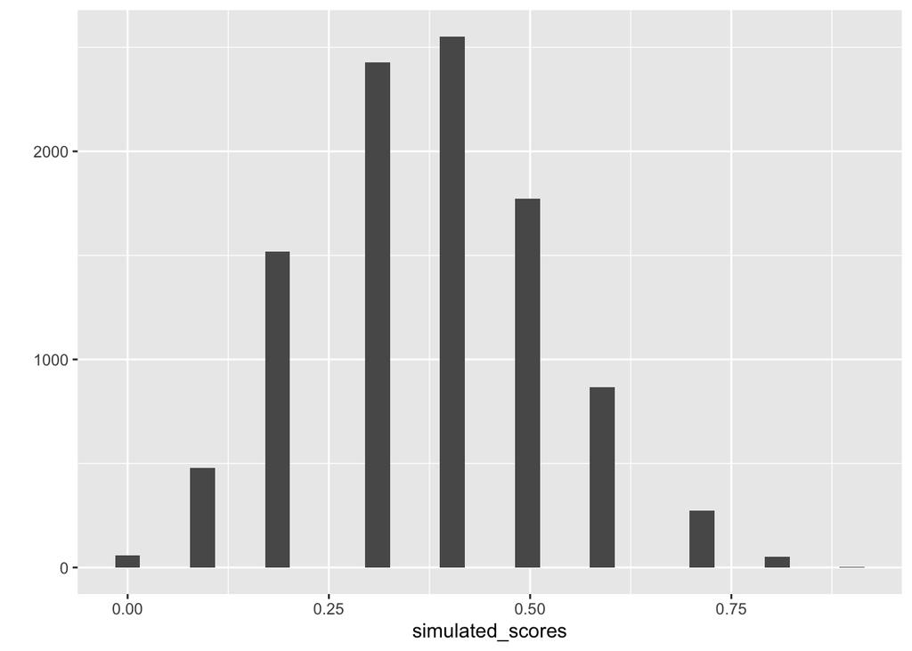

```r
simulated_test <- replicate(10000, rbinom(n = rep(1,10), size = 1, prob = c(.5,.5,.5,.5,.5,.25,.25,.25,.25,.25)))

simulated_scores <- colSums(simulated_test)/10

library(ggplot2)

qplot(simulated_scores)+
  geom_histogram()
```

```r
length(simulated_scores[simulated_scores > .75]) / 10000
```

```
## [1] 0.0055
```